# Part 1: Quality Control and Normalization

UFHCI BCB-SR Bioinformatics Unit

2026-04-08

## Overview

Before testing for differential expression, we need to assess sample quality, remove genes that are too lowly expressed to test reliably, and normalize the data so that samples are comparable.

**In this notebook you will:**

- Load count data and sample metadata
- Create a DGEList object
- Filter lowly expressed genes
- Apply TMM normalization
- Visualize sample quality

**Output:** A normalized DGEList saved as `DGE_filtered_normalized.rds` for use in the differential expression script.

## Setup

Load required packages and define output directories.

```r
library(limma)
library(edgeR)
library(tidyverse)
library(pheatmap)
library(RColorBrewer)
library(ggrepel)
library(here)

set.seed(42)

figures_dir <- here("demo-analysis", "output", "02-differential-expression", "figures")
rds_dir     <- here("demo-analysis", "output", "02-differential-expression")

dir.create(figures_dir, showWarnings = FALSE, recursive = TRUE)
dir.create(rds_dir,     showWarnings = FALSE, recursive = TRUE)
```

```r
counts_file   <- here("demo-analysis", "output", "01-prepared-data",
                      "rsem.merged.gene_counts.tsv")
metadata_file <- here("demo-analysis", "data", "metadata", "sample_metadata.csv")

if (!file.exists(counts_file))   stop("Count file not found: ",    counts_file)
if (!file.exists(metadata_file)) stop("Metadata file not found: ", metadata_file)

cat("✓ Count file found\n")
```

```
## ✓ Count file found
```

```r
cat("✓ Metadata file found\n")
```

```
## ✓ Metadata file found
```

## Load Data

### Gene Counts

The nf-core/rnaseq pipeline with RSEM produces a merged count matrix. We need the raw expected counts (`rsem.merged.gene_counts.tsv`), not the TPM or scaled variants.

```r
expression_data <- read.table(counts_file,
                               header      = TRUE,
                               row.names   = 1,
                               check.names = FALSE)

cat("Genes:", nrow(expression_data), "| Samples:", ncol(expression_data), "\n")
```

```
## Genes: 45706 | Samples: 6
```

```r
head(expression_data, n = 3)
```

```
##       SRR12546980 SRR12546982 SRR12546984 SRR12546986 SRR12546988 SRR12546990
## Gnai3        2660        3405        2947        2999        3012        3593
## Pbsn            0           0           0           0           0           0
## Cdc45        1528         989        1527         832        1431         961
```

### Sample Metadata

```r
sample_info <- read.csv(metadata_file,
                         header           = TRUE,
                         stringsAsFactors = FALSE)

sample_info
```

```
##        sample    group genotype treatment         Run
## 1 SRR12546980 PRMT7_WT PRMT7_WT Untreated SRR12546980
## 2 SRR12546982 PRMT7_KD PRMT7_KD Untreated SRR12546982
## 3 SRR12546984 PRMT7_WT PRMT7_WT Untreated SRR12546984
## 4 SRR12546986 PRMT7_KD PRMT7_KD Untreated SRR12546986
## 5 SRR12546988 PRMT7_WT PRMT7_WT Untreated SRR12546988
## 6 SRR12546990 PRMT7_KD PRMT7_KD Untreated SRR12546990
```

```r
# Confirm sample names match count matrix columns
all(sample_info$sample %in% colnames(expression_data))
```

```
## [1] TRUE
```

## Create DGEList Object

The `DGEList` object bundles counts and sample metadata into a single container used throughout the edgeR and limma-voom workflow.

```r
DGE <- DGEList(counts  = expression_data,
               samples = sample_info)

# Set the group factor explicitly — WT is the reference level (listed first)
DGE$samples$group <- factor(DGE$samples$genotype,
                              levels = c("PRMT7_WT", "PRMT7_KD"))
DGE
```

```
## An object of class "DGEList"
## $counts
##       SRR12546980 SRR12546982 SRR12546984 SRR12546986 SRR12546988 SRR12546990
## Gnai3        2660        3405        2947        2999        3012        3593
## Pbsn            0           0           0           0           0           0
## Cdc45        1528         989        1527         832        1431         961
## H19             0           0           0           0           0           0
## Scml2         273         213         323         188         323         203
## 45701 more rows ...
##
## $samples
##                group lib.size norm.factors      sample genotype treatment
## SRR12546980 PRMT7_WT 24337059            1 SRR12546980 PRMT7_WT Untreated
## SRR12546982 PRMT7_KD 29234454            1 SRR12546982 PRMT7_KD Untreated
## SRR12546984 PRMT7_WT 25754726            1 SRR12546984 PRMT7_WT Untreated
## SRR12546986 PRMT7_KD 25530602            1 SRR12546986 PRMT7_KD Untreated
## SRR12546988 PRMT7_WT 25440551            1 SRR12546988 PRMT7_WT Untreated
## SRR12546990 PRMT7_KD 29756203            1 SRR12546990 PRMT7_KD Untreated
##                     Run
## SRR12546980 SRR12546980
## SRR12546982 SRR12546982
## SRR12546984 SRR12546984
## SRR12546986 SRR12546986
## SRR12546988 SRR12546988
## SRR12546990 SRR12546990
```

## Filter Lowly Expressed Genes

Genes with very low counts across all samples add noise without contributing useful signal and inflate the multiple testing burden. `filterByExpr()` applies a principled heuristic: a gene must reach a minimum expression level in enough samples given the experimental design.

```r
keep.exprs <- filterByExpr(DGE, group = DGE$samples$group)
table(keep.exprs)
```

```
## keep.exprs
## FALSE  TRUE
## 31923 13783
```

```r
DGE <- DGE[keep.exprs, , keep.lib.sizes = FALSE]
cat("Genes remaining after filtering:", nrow(DGE), "\n")
```

```
## Genes remaining after filtering: 13783
```

## TMM Normalization

Even after filtering, samples differ in library size (total reads) and composition bias (a few highly expressed genes can dominate the library). TMM normalization calculates a scaling factor for each sample to correct for both. Factors close to 1.0 indicate little correction was needed.

```r
DGE <- calcNormFactors(DGE, method = "TMM")
DGE$samples
```

```
##                group lib.size norm.factors      sample genotype treatment
## SRR12546980 PRMT7_WT 24323440    0.9658797 SRR12546980 PRMT7_WT Untreated
## SRR12546982 PRMT7_KD 29211491    1.0310303 SRR12546982 PRMT7_KD Untreated
## SRR12546984 PRMT7_WT 25741291    0.9680730 SRR12546984 PRMT7_WT Untreated
## SRR12546986 PRMT7_KD 25511002    1.0323240 SRR12546986 PRMT7_KD Untreated
## SRR12546988 PRMT7_WT 25427173    0.9659082 SRR12546988 PRMT7_WT Untreated
## SRR12546990 PRMT7_KD 29730447    1.0402687 SRR12546990 PRMT7_KD Untreated
##                     Run
## SRR12546980 SRR12546980
## SRR12546982 SRR12546982
## SRR12546984 SRR12546984
## SRR12546986 SRR12546986
## SRR12546988 SRR12546988
## SRR12546990 SRR12546990
```

## Quality Control

### Library Sizes

Library size is the total number of reads per sample after filtering. Large differences (>2–3×) between samples may indicate technical issues. Moderate variation is normal and is handled by normalization.

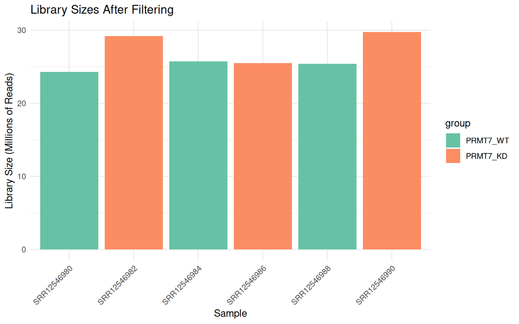

```r
lib_size_df <- data.frame(
  sample   = rownames(DGE$samples),
  lib_size = DGE$samples$lib.size,
  group    = DGE$samples$group
)

ggplot(lib_size_df, aes(x = sample, y = lib_size / 1e6, fill = group)) +
  geom_col() +
  labs(title = "Library Sizes After Filtering",
       x = "Sample", y = "Library Size (Millions of Reads)") +
  theme_minimal() +
  theme(axis.text.x = element_text(angle = 45, hjust = 1)) +
  scale_fill_brewer(palette = "Set2")
```

### MDS Plot

Multidimensional Scaling (MDS) places samples in two-dimensional space such that similar samples are closer together. Samples from the same group should cluster together and separate clearly from the other group. Outlier samples or unexpected clustering patterns are red flags.

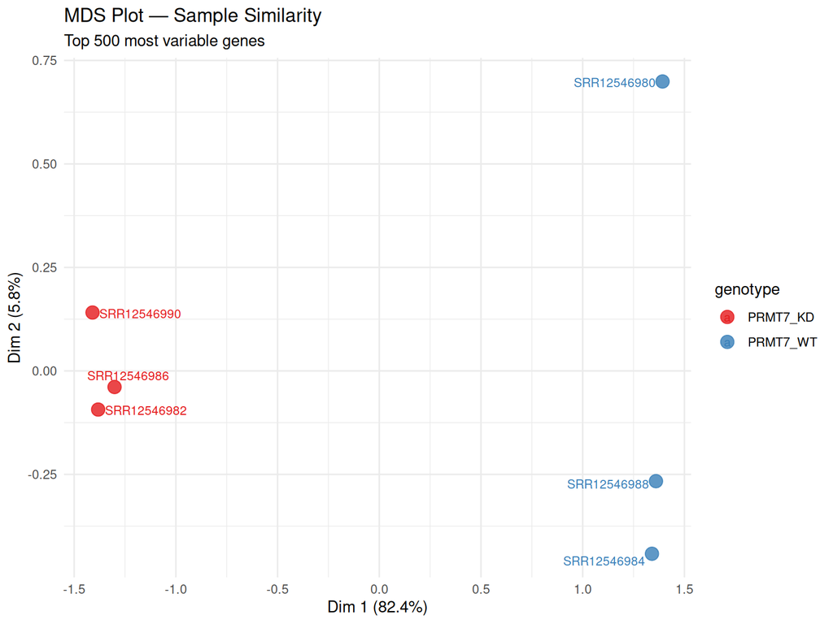

```r
mds <- plotMDS(DGE, top = 500, plot = FALSE, gene.selection = "common")

mds_df <- data.frame(
  sample   = rownames(DGE$samples),
  dim1     = mds$x,
  dim2     = mds$y,
  genotype = DGE$samples$genotype
)

ggplot(mds_df, aes(x = dim1, y = dim2, color = genotype, label = sample)) +
  geom_point(size = 4, alpha = 0.8) +
  geom_text_repel(size = 3, max.overlaps = 20) +
  labs(title    = "MDS Plot — Sample Similarity",
       subtitle = "Top 500 most variable genes",
       x = paste0("Dim 1 (", round(mds$var.explained[1] * 100, 1), "%)"),
       y = paste0("Dim 2 (", round(mds$var.explained[2] * 100, 1), "%)")) +
  theme_minimal() +
  scale_color_brewer(palette = "Set1")
```

```r
ggsave(here(figures_dir, "mds_plot.png"), width = 8, height = 6, dpi = 300)
```

### Sample Correlation Heatmap

Pairwise Spearman correlations between all samples. Samples in the same group should show higher correlations with each other than with samples in the other group. Typical within-group correlations are 0.95–0.99.

```r
logcpm     <- cpm(DGE, log = TRUE)
cor_matrix <- cor(logcpm, method = "spearman")

annotation_col <- data.frame(
  Genotype  = DGE$samples$genotype,
  row.names = colnames(logcpm)
)

# Save to file
pheatmap(cor_matrix,
         annotation_col = annotation_col,
         annotation_row = annotation_col,
         main     = "Sample Correlation Heatmap",
         color    = colorRampPalette(c("blue", "white", "red"))(100),
         breaks   = seq(0.7, 1, length.out = 101),
         fontsize = 8,
         filename = here(figures_dir, "correlation_heatmap.png"),
         width = 8, height = 7)

# Display in document
pheatmap(cor_matrix,
         annotation_col = annotation_col,
         annotation_row = annotation_col,
         main     = "Sample Correlation Heatmap",
         color    = colorRampPalette(c("blue", "white", "red"))(100),
         breaks   = seq(0.7, 1, length.out = 101),
         fontsize = 8)
```

[output not shown]

## Save Processed Data

Save the filtered and normalized DGEList so the differential expression script can load it directly without re-running QC.

```r
saveRDS(DGE, file = here(rds_dir, "DGE_filtered_normalized.rds"))

cat("✓ Saved:", here(rds_dir, "DGE_filtered_normalized.rds"), "\n")
```

```
## ✓ Saved: /blue/bioinf_workshop/hkates/rnaseq_workshop/demo-analysis/output/02-differential-expression/DGE_filtered_normalized.rds
```

```r
cat("  Genes:", nrow(DGE), "| Samples:", ncol(DGE), "\n")
```

```
##   Genes: 13783 | Samples: 6
```

```r
cat("  Groups:", paste(levels(DGE$samples$group), collapse = ", "), "\n")
```

```
##   Groups: PRMT7_WT, PRMT7_KD
```